# 分析过程

### 导入相关包

```python
import pandas as pd
import numpy as np
import codecs
import warnings
import matplotlib.pyplot as plt
import seaborn as sns
from pyecharts import *
warnings.filterwarnings('ignore')
%matplotlib inline
sns.set(style="darkgrid")
# sns.set_style('whitegrid')
```

### 观察customer.csv内容信息

```python
customer = pd.read_csv('./customer.csv')
customer.head()
```

|  | customer_id | store_id | first_name | last_name | email | address_id | active | create_date | last_update |
| --- | --- | --- | --- | --- | --- | --- | --- | --- | --- |
| 0 | 1 | 1 | MARY | SMITH | MARY.SMITH@sakilacustomer.org | 5 | 1 | 2006-02-14 22:04:36 | 2006-02-15 04:57:20 |
| 1 | 2 | 1 | PATRICIA | JOHNSON | PATRICIA.JOHNSON@sakilacustomer.org | 6 | 1 | 2006-02-14 22:04:36 | 2006-02-15 04:57:20 |
| 2 | 3 | 1 | LINDA | WILLIAMS | LINDA.WILLIAMS@sakilacustomer.org | 7 | 1 | 2006-02-14 22:04:36 | 2006-02-15 04:57:20 |
| 3 | 4 | 2 | BARBARA | JONES | BARBARA.JONES@sakilacustomer.org | 8 | 1 | 2006-02-14 22:04:36 | 2006-02-15 04:57:20 |
| 4 | 5 | 1 | ELIZABETH | BROWN | ELIZABETH.BROWN@sakilacustomer.org | 9 | 1 | 2006-02-14 22:04:36 | 2006-02-15 04:57:20 |

#### 简单分析之后决定去掉顾客名字、邮箱、时间等无用信息

```python
customer = customer.loc[:,['customer_id','store_id','active']]
customer.head()
```

|  | customer_id | store_id | active |
| --- | --- | --- | --- |
| 0 | 1 | 1 | 1 |
| 1 | 2 | 1 | 1 |
| 2 | 3 | 1 | 1 |
| 3 | 4 | 2 | 1 |
| 4 | 5 | 1 | 1 |

### 查看rental.csv内容

```python
rental = pd.read_csv('./rental.csv')
rental.head(5)
```

|  | rental_id | rental_date | inventory_id | customer_id | return_date | staff_id | last_update |
| --- | --- | --- | --- | --- | --- | --- | --- |
| 0 | 1 | 2005-05-24 22:53:30 | 367 | 130 | 2005-05-26 22:04:30 | 1 | 2006-02-15 21:30:53 |
| 1 | 2 | 2005-05-24 22:54:33 | 1525 | 459 | 2005-05-28 19:40:33 | 1 | 2006-02-15 21:30:53 |
| 2 | 3 | 2005-05-24 23:03:39 | 1711 | 408 | 2005-06-01 22:12:39 | 1 | 2006-02-15 21:30:53 |
| 3 | 4 | 2005-05-24 23:04:41 | 2452 | 333 | 2005-06-03 01:43:41 | 2 | 2006-02-15 21:30:53 |
| 4 | 5 | 2005-05-24 23:05:21 | 2079 | 222 | 2005-06-02 04:33:21 | 1 | 2006-02-15 21:30:53 |

#### 根据租借和归还日期得到租赁时长(单位day)

```python
import datetime
rental.sort_values(by='customer_id', inplace=True)
lease_time = []
for i in range(len(rental)):
    try:
        d1 = datetime.datetime.strptime(rental.loc[i,:]['rental_date'],'%Y-%m-%d %H:%M:%S')
        d2 = datetime.datetime.strptime(rental.loc[i,:]['return_date'],'%Y-%m-%d %H:%M:%S')
        d3 = d2-d1
        rent_time = d3.days + round(d3.seconds/86400, 2)
        lease_time.append(rent_time)
    except:
#         print(i)
        rent_time = 3600
        lease_time.append(rent_time)
rental = rental.loc[:,['rental_id','customer_id','staff_id']]
rental['lease_time'] = lease_time
rental.head(5)
```

|  | rental_id | customer_id | staff_id | lease_time |
| --- | --- | --- | --- | --- |
| 5323 | 5326 | 1 | 1 | 1.97 |
| 1723 | 1725 | 1 | 1 | 3.87 |
| 11819 | 11824 | 1 | 2 | 7.96 |
| 8322 | 8326 | 1 | 2 | 9.11 |
| 1183 | 1185 | 1 | 2 | 8.23 |

```python
rental.head(1)
```

|  | rental_id | customer_id | staff_id | lease_time |
| --- | --- | --- | --- | --- |
| 5323 | 5326 | 1 | 1 | 1.97 |

#### 将所有customer_id相同的信息组合

```python
flag = 1
rental_ids = []
staff_ids = []
lease_time_sum = 0
# new_rental = pd.DataFrame(columns=('customer_id', 'rental_ids', 'staff_ids', 'lease_time'))
new_rental = pd.DataFrame()
for i in range(len(rental)):
    tempseries = rental.iloc[i]
    if tempseries['customer_id'] == flag:
        rental_ids.append(tempseries.rental_id)
        staff_ids.append(tempseries.staff_id)
        lease_time_sum += tempseries.lease_time

    else:
#         print(flag)
#         print(rental_ids)
#         print(staff_ids
#         print(lease_time_sum)
        tempDF = {'customer_id':int(flag),
            'rental_ids':" ".join(map(lambda x:str(x),rental_ids)),
            'staff_ids':" ".join(map(lambda x:str(x),staff_ids)),
            'lease_time':int(lease_time_sum)
            }
        new_rental = new_rental.append(tempDF,ignore_index=True)
        rental_ids = []
        staff_ids = []
        lease_time_sum = 0
        flag+=1
```

#### 处理之后的信息

```python
print("长度：",len(new_rental))
new_rental.head()
```

```
长度： 598
```

|  | customer_id | lease_time | rental_ids | staff_ids |
| --- | --- | --- | --- | --- |
| 0 | 1.0 | 136.0 | 5326.0 1725.0 11824.0 8326.0 1185.0 6163.0 147... | 1.0 1.0 2.0 2.0 2.0 2.0 1.0 1.0 1.0 2.0 2.0 2.... |
| 1 | 2.0 | 121.0 | 8598.0 10918.0 8705.0 12963.0 2128.0 10466.0 7... | 2.0 1.0 1.0 2.0 2.0 1.0 2.0 1.0 2.0 1.0 2.0 1.... |
| 2 | 3.0 | 123.0 | 7096.0 7911.0 14699.0 9816.0 12556.0 1546.0 15... | 2.0 1.0 2.0 2.0 2.0 1.0 1.0 1.0 1.0 2.0 2.0 2.... |
| 3 | 4.0 | 120.0 | 9100.0 11110.0 8741.0 12294.0 13807.0 11529.0 ... | 1.0 2.0 2.0 2.0 2.0 2.0 1.0 1.0 2.0 1.0 1.0 1.... |
| 4 | 5.0 | 192.0 | 1502.0 11001.0 11930.0 7293.0 8978.0 15232.0 8... | 2.0 1.0 1.0 2.0 1.0 1.0 2.0 2.0 2.0 1.0 1.0 1.... |

### 查看payment.csv内容

```python
payment = pd.read_csv('./payment.csv')
payment.head(5)
```

|  | payment_id | customer_id | staff_id | rental_id | amount | payment_date | last_update |
| --- | --- | --- | --- | --- | --- | --- | --- |
| 0 | 1 | 1 | 1 | 76.0 | 2.99 | 2005-5-25 11:30 | 2006-2-15 22:12 |
| 1 | 2 | 1 | 1 | 573.0 | 0.99 | 2005-5-28 10:35 | 2006-2-15 22:12 |
| 2 | 3 | 1 | 1 | 1185.0 | 5.99 | 2005-6-15 0:54 | 2006-2-15 22:12 |
| 3 | 4 | 1 | 2 | 1422.0 | 0.99 | 2005-6-15 18:02 | 2006-2-15 22:12 |
| 4 | 5 | 1 | 2 | 1476.0 | 9.99 | 2005-6-15 21:08 | 2006-2-15 22:12 |

#### 去除日期，租用ID，货架ID等冗余信息

```python
payment = payment.loc[:,['payment_id','customer_id','amount']]
payment.head(5)
```

|  | payment_id | customer_id | amount |
| --- | --- | --- | --- |
| 0 | 1 | 1 | 2.99 |
| 1 | 2 | 1 | 0.99 |
| 2 | 3 | 1 | 5.99 |
| 3 | 4 | 1 | 0.99 |
| 4 | 5 | 1 | 9.99 |

#### 整合相同customer_id的amount ，将所有相同customer_id的amount求和

```python
flag = 1
amounts = 0
new_payment = pd.DataFrame()
for i in range(len(payment)):
    tempseries = payment.iloc[i]
    if tempseries['customer_id'] == flag:
        amounts += tempseries.amount
    else:
        tempDF = {'customer_id':flag,
            'amount_sum':int(amounts)
            }
        new_payment = new_payment.append(tempDF,ignore_index=True)
        amounts = 0
        flag+=1
```

```python
new_payment.head(5)
```

|  | amount_sum | customer_id |
| --- | --- | --- |
| 0 | 118.0 | 1.0 |
| 1 | 123.0 | 2.0 |
| 2 | 133.0 | 3.0 |
| 3 | 76.0 | 4.0 |
| 4 | 143.0 | 5.0 |

### 将前面几个表通过customer_id连接起来，得到最终顾客消费信息

```python
data = pd.merge(new_rental, new_payment)
data = pd.merge(data, customer)
data.head()
```

|  | customer_id | lease_time | rental_ids | staff_ids | amount_sum | store_id | active |
| --- | --- | --- | --- | --- | --- | --- | --- |
| 0 | 1 | 136.0 | 5326.0 1725.0 11824.0 8326.0 1185.0 6163.0 147... | 1.0 1.0 2.0 2.0 2.0 2.0 1.0 1.0 1.0 2.0 2.0 2.... | 118.0 | 1 | 1 |
| 1 | 2 | 121.0 | 8598.0 10918.0 8705.0 12963.0 2128.0 10466.0 7... | 2.0 1.0 1.0 2.0 2.0 1.0 2.0 1.0 2.0 1.0 2.0 1.... | 123.0 | 1 | 1 |
| 2 | 3 | 123.0 | 7096.0 7911.0 14699.0 9816.0 12556.0 1546.0 15... | 2.0 1.0 2.0 2.0 2.0 1.0 1.0 1.0 1.0 2.0 2.0 2.... | 133.0 | 1 | 1 |
| 3 | 4 | 120.0 | 9100.0 11110.0 8741.0 12294.0 13807.0 11529.0 ... | 1.0 2.0 2.0 2.0 2.0 2.0 1.0 1.0 2.0 1.0 1.0 1.... | 76.0 | 2 | 1 |
| 4 | 5 | 192.0 | 1502.0 11001.0 11930.0 7293.0 8978.0 15232.0 8... | 2.0 1.0 1.0 2.0 1.0 1.0 2.0 2.0 2.0 1.0 1.0 1.... | 143.0 | 1 | 1 |

#### 将rental_id和staff_id整理为租借频次

```python
data['rental_ids'] = data['rental_ids'].apply(lambda x:sum([1 for i in x.split(" ")]))
data['staff_ids'] = data['staff_ids'].apply(lambda x:sum([1 for i in x.split(" ")]))
```

```python
data.head()
```

|  | customer_id | lease_time | rental_ids | staff_ids | amount_sum | store_id | active |
| --- | --- | --- | --- | --- | --- | --- | --- |
| 0 | 1 | 136.0 | 32 | 32 | 118.0 | 1 | 1 |
| 1 | 2 | 121.0 | 26 | 26 | 123.0 | 1 | 1 |
| 2 | 3 | 123.0 | 25 | 25 | 133.0 | 1 | 1 |
| 3 | 4 | 120.0 | 21 | 21 | 76.0 | 2 | 1 |
| 4 | 5 | 192.0 | 37 | 37 | 143.0 | 1 | 1 |

#### 经结合实际分析租用次数和存货取出次数一致，并且商店编号不影响顾客消费预测， 这里将次数统一成租用频次并且丢掉商店编号

```python
data.drop(['staff_ids', 'store_id'], axis=1, inplace=True)
data.columns = ['customer_id', 'lease_time', 'frequency', 'amount_sum', 'active']
```

```python
data[['customer_id']] = data[['customer_id']].astype('int')
data.head(5)
```

|  | customer_id | lease_time | frequency | amount_sum | active |
| --- | --- | --- | --- | --- | --- |
| 0 | 1 | 136.0 | 32 | 118.0 | 1 |
| 1 | 2 | 121.0 | 26 | 123.0 | 1 |
| 2 | 3 | 123.0 | 25 | 133.0 | 1 |
| 3 | 4 | 120.0 | 21 | 76.0 | 1 |
| 4 | 5 | 192.0 | 37 | 143.0 | 1 |

### 特征说明：customer_id ：用户ID；

### lease_time ：用户租借总时长（单位 天）

### frequency：用户租借总频次

### amount_sum：消费总金额，单位美元

### active：账户是否激活，1表示激活，0表示未激活

```python
#将data写入CSV
# data.to_csv('./data.csv', index=False)
```

```python
#查看数据信息
data.info()
```

```
<class 'pandas.core.frame.DataFrame'>
Int64Index: 598 entries, 0 to 597
Data columns (total 5 columns):
customer_id    598 non-null int32
lease_time     598 non-null float64
frequency      598 non-null int64
amount_sum     598 non-null float64
active         598 non-null int64
dtypes: float64(2), int32(1), int64(2)
memory usage: 25.7 KB
```

#### 观察上面数据发现无缺省值

```python
#查看数据统计分布
data.describe()
```

|  | customer_id | lease_time | frequency | amount_sum | active |
| --- | --- | --- | --- | --- | --- |
| count | 598.000000 | 598.000000 | 598.000000 | 598.000000 | 598.000000 |
| mean | 299.500000 | 1181.197324 | 25.799331 | 107.673913 | 0.974916 |
| std | 172.772008 | 2539.963894 | 5.106556 | 25.402403 | 0.156510 |
| min | 1.000000 | 59.000000 | 11.000000 | 42.000000 | 0.000000 |
| 25% | 150.250000 | 113.000000 | 22.000000 | 90.000000 | 1.000000 |
| 50% | 299.500000 | 136.500000 | 25.000000 | 106.000000 | 1.000000 |
| 75% | 448.750000 | 170.000000 | 29.000000 | 124.000000 | 1.000000 |
| max | 598.000000 | 14504.000000 | 45.000000 | 216.000000 | 1.000000 |

#### 上表为顾客租用记录的基本统计分布

# 数据分析

### 分析lease_time的数据分布

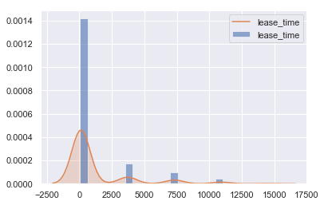

```python
# data['lease_time'].plot(kind='kde')
fig, ax = plt.subplots()
ax.hist(data['lease_time'], bins=25,
        histtype="stepfilled", normed=True, alpha=0.6)
sns.kdeplot(data['lease_time'], shade=True)
sns.set_style('whitegrid')
```

#### 上面做出lease_time的核密度图，发现其分布存在严重偏差，下面对其具体数据具体分析，查找异常值

#### 我们通过大致的分析决定将满足与期望做差的绝对值大于3倍方差的值（即 abs(value - u）> 3 * std），以及数值直接大于2000的作为异常值

```python
# 找出异常值
u = data['lease_time'].mean()
std = data['lease_time'].std()
correct_value = []
errors = []
for i in range(len(data)):
    tempvalue = data.iloc[i]['lease_time']
    if np.abs(tempvalue-u) > 3*std or tempvalue > 2000:
        errors.append([i, tempvalue])
    else:
        correct_value.append([i, tempvalue])
print("理论异常值有{}个".format(len(errors)))
```

```
理论异常值有108个
```

### 做出lease_time数据点的分布图（正态性检验）

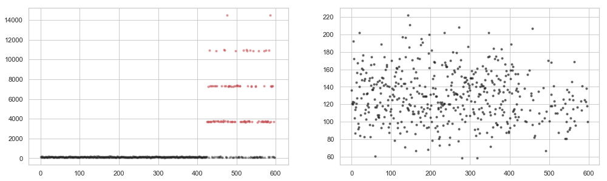

```python
figure, ax = plt.subplots(1,2)
#绘制图一
ax[0].scatter([i[0] for i in correct_value], [i[1] for i in correct_value], color = 'k', marker='.', alpha = 0.3)
ax[0].scatter([i[0] for i in errors], [i[1] for i in errors], color = 'r', marker='.', alpha = 0.5)
#绘制图二
ax[1].scatter([i[0] for i in correct_value], [i[1] for i in correct_value], color = 'k', marker='.', alpha = 0.6)
plt.subplots_adjust(bottom=0.1, right=2.3, top=1)
sns.set_style('darkgrid')
```

#### 做出租借时间lease_time的散点图（红色为理论异常值，黑色为理论正确值） ，左图为所有数据分布情况，右图为正确值的分布情况

#### 接下来对异常值进行填补

```python
# 处理lease_time的异常值（用75%分位数~除去异常值之后的最大值之间的随机数填补）
from random import randint
data['lease_time'] = data['lease_time'].apply(lambda x: randint(136,222) if x in [i[1] for i in errors] else x)
```

```python
data.describe()
```

|  | customer_id | lease_time | frequency | amount_sum | active |
| --- | --- | --- | --- | --- | --- |
| count | 598.000000 | 598.000000 | 598.000000 | 598.000000 | 598.000000 |
| mean | 299.500000 | 137.102007 | 25.799331 | 107.673913 | 0.974916 |
| std | 172.772008 | 33.078374 | 5.106556 | 25.402403 | 0.156510 |
| min | 1.000000 | 59.000000 | 11.000000 | 42.000000 | 0.000000 |
| 25% | 150.250000 | 113.000000 | 22.000000 | 90.000000 | 1.000000 |
| 50% | 299.500000 | 136.000000 | 25.000000 | 106.000000 | 1.000000 |
| 75% | 448.750000 | 158.000000 | 29.000000 | 124.000000 | 1.000000 |
| max | 598.000000 | 222.000000 | 45.000000 | 216.000000 | 1.000000 |

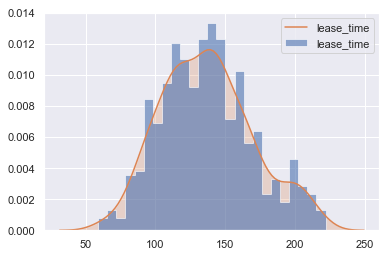

```python
fig, ax = plt.subplots()
ax.hist(data['lease_time'], bins=25,
        histtype="stepfilled", normed=True, alpha=0.6)
sns.kdeplot(data['lease_time'], shade=True)
sns.set(style="darkgrid")
```

#### 以上为填补完之后的数据，大致能够反映lease_time分布的真实分布趋势（趋近于高斯分布）

#### 此处可以尝试采取其他插值法，例如排除异常值后采取拉格朗日插值法，效果会更好，更加逼近高斯分布

### 下面分析frequency和amount_sum分布，做出其核密度图发现其分布逐渐靠近高斯分布

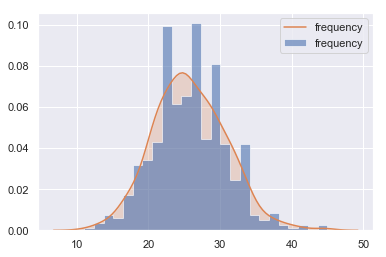

```python
# data['frequency'].plot(kind='kde', style = '--')
fig, ax = plt.subplots()
ax.hist(data['frequency'], bins=25,
        histtype="stepfilled", normed=True, alpha=0.6)
sns.kdeplot(data['frequency'], shade=True)
```

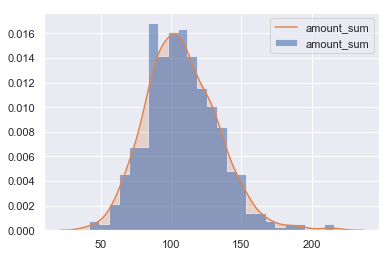

```python
# data['amount_sum'].plot(kind='kde', style = '--')
fig, ax = plt.subplots()
ax.hist(data['amount_sum'], bins=25,
        histtype="stepfilled", normed=True, alpha=0.6)
sns.kdeplot(data['amount_sum'], shade=True)
```

### 下面做出lease_time散点图

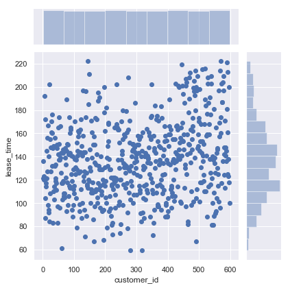

```python
# plt.scatter(list(range(598)), data['lease_time'], marker='o')
# plt.xlabel('lease_time散点分布')
sns.jointplot(x='customer_id', y='lease_time', data=data, size=(6))
```

#### 上图可以看出经过异常处理后的lease_time分布已经大致可以反映分布情况

### 下面做出frequency散点图

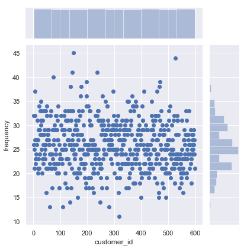

```python
sns.jointplot(x='customer_id', y='frequency', data=data, size=(6))
```

### 下面做出amount_sum的散点图

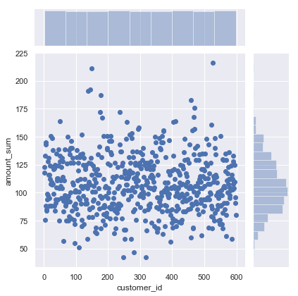

```python
sns.jointplot(x='customer_id', y='amount_sum', data=data, size=(6))
```

### 从上面三张图可以很明显的看出每个特征的数据分布都具有一定的相似性

### 我们可以根据上面的数据特征组合总结出顾客的消费评价指标

# 顾客分类方案实现

#### 根据实际情况我猜测最终的消费指标的形式为各列特征线性相加（ind = w1*x1 + w2*x2 + ..... +wi*xi）

#### 经过分析各项权重分配如下：lease_time*0.2 + frequency*0.25 + amount_sum*0.45 + active*0.1

```python
df = pd.DataFrame()
for i in range(len(data)):
    tempseries = data.iloc[i]
    indicator = tempseries[1]*0.2 + tempseries[2]*0.25 + tempseries[3]*0.45 + tempseries[4]*0.1
    tempDF = {'customer_id':i+1,
              'indicator':indicator
            }
    df = df.append(tempDF,ignore_index=True)
df[['customer_id']] = df[['customer_id']].astype('int')
```

#### 经过加权和处理后数据样式如下

```python
df.head()
```

|  | customer_id | indicator |
| --- | --- | --- |
| 0 | 1 | 88.40 |
| 1 | 2 | 86.15 |
| 2 | 3 | 90.80 |
| 3 | 4 | 63.55 |
| 4 | 5 | 112.10 |

#### 加权指标分布散点图如下，可以看出经过加权处理之后的数据基本拟合以前分散数据所具有的特征

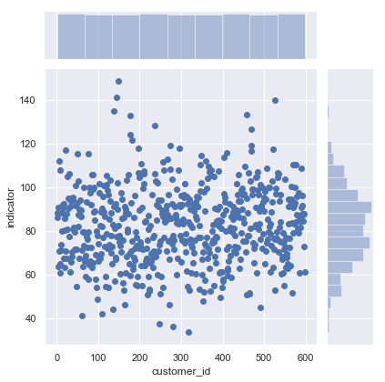

```python
sns.jointplot(x='customer_id', y='indicator', data=df, size=(6))
```

|  | customer_id | indicator |
| --- | --- | --- |
| count | 598.000000 | 598.000000 |
| mean | 299.500000 | 82.420987 |
| std | 172.772008 | 17.404712 |
| min | 1.000000 | 33.550000 |
| 25% | 150.250000 | 70.600000 |
| 50% | 299.500000 | 82.200000 |
| 75% | 448.750000 | 93.712500 |
| max | 598.000000 | 148.500000 |

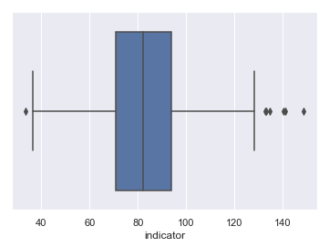

```python
sns.boxplot(x='indicator', data=df)
df.describe()
```

### 上面列出了顾客消费指标(indicator)的基本统计数据，并根据数据做出了箱线图，可以看到整体数据的平均值和50%分位数都在82~83之间，根据显示出来的统计规律以及结合销售实际，往往处于中位的顾客最具有消费能力，因此本次的消费者分类任务，可以简单近似地凭借其综合消费指标(indicator)的50%分位数作为是否是积极用户的判断依据，我们认为大于50%的为积极消费者，对于潜在的消费力我们按照平均值以下1/2个方差~平均值以上1个方差这一区间为波动范围内来确定，即在（mean - 0.5*std ~ mean + std）范围内我们都认定为具有潜在消费力的顾客

```
Text(200,-2,'Graphic(3)')
```

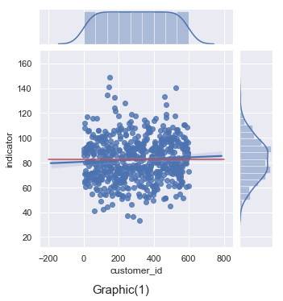

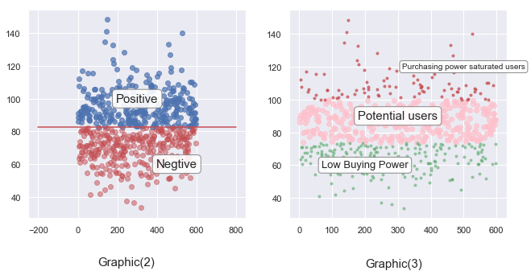

```python
sns.jointplot(x='customer_id', y='indicator', data=df, kind="reg", size=(5))
plt.plot(np.linspace(-200,800),[82.5]*50, color='r')
plt.text(50, -25, 'Graphic(1)', fontsize=15)
fig, axes=plt.subplots(1,2)
plt.subplots_adjust(bottom=0.1, right=1.5, top=1)
pos = []
neg = []
poten = []
no_poten = []
saturated = []
low = []
u, std = df['indicator'].mean(), df['indicator'].std()
for index,value in enumerate(df['indicator']):
    index += 1
    if value >= 82.5:
        pos.append([index, value])
    if value >= u-std*0.5 and value <= u+std:
        poten.append([index, value])
    if value < u-std*0.5 or value > u+std:
        no_poten.append([index, value])
        if value > u+std:
            saturated.append([index, value])
        else:
            low.append([index, value])
    if value < 82.5:
        neg.append([index, value])

axes[0].scatter([i[0] for i in pos], [i[1] for i in pos], color = 'b', marker='o', alpha = 0.7)
axes[0].scatter([i[0] for i in neg], [i[1] for i in neg], color = 'r', marker='o', alpha = 0.5)
axes[0].plot(np.linspace(-200,800),[82.5]*50, color='r')
bbox_props = dict(boxstyle="round", fc="w", ec="0.5", alpha=0.9)
axes[0].text(500, 60, "Negtive", ha="center", va="center", size=15,
    bbox=bbox_props)
axes[0].text(300, 100, "Positive", ha="center", va="center", size=15,
    bbox=bbox_props)
axes[0].text(100, -2, 'Graphic(2)', fontsize=15)

axes[1].scatter([i[0] for i in poten], [i[1] for i in poten], color = 'pink', marker='o', alpha = 0.7)
axes[1].scatter([i[0] for i in low], [i[1] for i in low], color = 'g', marker='.', alpha = 0.5)
axes[1].scatter([i[0] for i in saturated], [i[1] for i in saturated], color = 'r', marker='.', alpha = 0.7)
axes[1].text(300, 90, "Potential users", ha="center", va="center", size=15,
    bbox=bbox_props)
axes[1].text(200, 60, "Low Buying Power", ha="center", va="center", size=13,
    bbox=bbox_props)
axes[1].text(500, 120, "Purchasing power saturated users", ha="center", va="center", size=10,
    bbox=bbox_props)
axes[1].text(200, -2, 'Graphic(3)', fontsize=15)
```

### 上面图（1）蓝色直线为数据的大致回归趋势，红色直线为我们选定的活跃与不活跃用户的划分依据（50%分位数），我们可以大致看出两条线趋于拟合，图（2）将活跃用户和不活跃用户作了划分，上面蓝色部分为活跃用户（Positive），下面红色部分为不够活跃的用户（Negative）,图（3）作出了对我们定义的潜力客户与非潜力客户的划分图，中间粉色区域为消费指标在平均值以下1/2个方差~平均值以上1个方差（mean - 0.5*std ~ mean + std）的用户群体（Potential users），我们将这一部分群体视为未来具有消费潜力的用户，我们预测这一部分用户的消费额在未来会增加；上面的红色区域为我们统计出来的消费饱和用户（"Purchasing power saturated users" , 大于mean + std）我们预计这一部分用户的消费可能存在饱和情况，在将来的消费中难以有提升，因此不纳入潜力消费用户范围；下方的绿色区域为我们认为的不活跃用户（"Low Buying Power" , 小于mean - 0.5*std），我们猜测这一部分用户消费力可能一直停留在此阶段，未来可能不会有继续增加消费量的想法，所有不纳入潜力消费用户的范围。

```python
#根据上面的划分方法，在customer表中筛选出具有潜在购买力的用户
potential_usr = pd.DataFrame()
customer = pd.read_csv('./customer.csv')
for i in range(len(customer)):
    if i in [x[0] for x in poten]:
        tempseries = customer.iloc[i]
        com_name = str(tempseries[2]) + " " + str(tempseries[3])
        email = tempseries[4]
        tempDict = {
            "customer_id":i+1,
            "name":com_name,
            "email":email
        }
        potential_usr = potential_usr.append(tempDict,ignore_index=True)
potential_usr[['customer_id']] = potential_usr[['customer_id']].astype('int')
```

# 结论

```python
potential_usr
```

|  | customer_id | email | name |
| --- | --- | --- | --- |
| 0 | 2 | PATRICIA.JOHNSON@sakilacustomer.org | PATRICIA JOHNSON |
| 1 | 3 | LINDA.WILLIAMS@sakilacustomer.org | LINDA WILLIAMS |
| 2 | 4 | BARBARA.JONES@sakilacustomer.org | BARBARA JONES |
| 3 | 12 | NANCY.THOMAS@sakilacustomer.org | NANCY THOMAS |
| 4 | 13 | KAREN.JACKSON@sakilacustomer.org | KAREN JACKSON |
| 5 | 14 | BETTY.WHITE@sakilacustomer.org | BETTY WHITE |
| 6 | 15 | HELEN.HARRIS@sakilacustomer.org | HELEN HARRIS |
| 7 | 16 | SANDRA.MARTIN@sakilacustomer.org | SANDRA MARTIN |
| 8 | 17 | DONNA.THOMPSON@sakilacustomer.org | DONNA THOMPSON |
| 9 | 20 | SHARON.ROBINSON@sakilacustomer.org | SHARON ROBINSON |
| 10 | 21 | MICHELLE.CLARK@sakilacustomer.org | MICHELLE CLARK |
| 11 | 24 | KIMBERLY.LEE@sakilacustomer.org | KIMBERLY LEE |
| 12 | 26 | JESSICA.HALL@sakilacustomer.org | JESSICA HALL |
| 13 | 28 | CYNTHIA.YOUNG@sakilacustomer.org | CYNTHIA YOUNG |
| 14 | 29 | ANGELA.HERNANDEZ@sakilacustomer.org | ANGELA HERNANDEZ |
| 15 | 31 | BRENDA.WRIGHT@sakilacustomer.org | BRENDA WRIGHT |
| 16 | 32 | AMY.LOPEZ@sakilacustomer.org | AMY LOPEZ |
| 17 | 33 | ANNA.HILL@sakilacustomer.org | ANNA HILL |
| 18 | 36 | KATHLEEN.ADAMS@sakilacustomer.org | KATHLEEN ADAMS |
| 19 | 39 | DEBRA.NELSON@sakilacustomer.org | DEBRA NELSON |
| 20 | 40 | AMANDA.CARTER@sakilacustomer.org | AMANDA CARTER |
| 21 | 41 | STEPHANIE.MITCHELL@sakilacustomer.org | STEPHANIE MITCHELL |
| 22 | 42 | CAROLYN.PEREZ@sakilacustomer.org | CAROLYN PEREZ |
| 23 | 43 | CHRISTINE.ROBERTS@sakilacustomer.org | CHRISTINE ROBERTS |
| 24 | 45 | JANET.PHILLIPS@sakilacustomer.org | JANET PHILLIPS |
| 25 | 46 | CATHERINE.CAMPBELL@sakilacustomer.org | CATHERINE CAMPBELL |
| 26 | 50 | DIANE.COLLINS@sakilacustomer.org | DIANE COLLINS |
| 27 | 53 | HEATHER.MORRIS@sakilacustomer.org | HEATHER MORRIS |
| 28 | 54 | TERESA.ROGERS@sakilacustomer.org | TERESA ROGERS |
| 29 | 55 | DORIS.REED@sakilacustomer.org | DORIS REED |
| ... | ... | ... | ... |
| 285 | 559 | EVERETT.BANDA@sakilacustomer.org | EVERETT BANDA |
| 286 | 560 | JORDAN.ARCHULETA@sakilacustomer.org | JORDAN ARCHULETA |
| 287 | 561 | IAN.STILL@sakilacustomer.org | IAN STILL |
| 288 | 563 | KEN.PREWITT@sakilacustomer.org | KEN PREWITT |
| 289 | 564 | BOB.PFEIFFER@sakilacustomer.org | BOB PFEIFFER |
| 290 | 566 | CASEY.MENA@sakilacustomer.org | CASEY MENA |
| 291 | 568 | ALBERTO.HENNING@sakilacustomer.org | ALBERTO HENNING |
| 292 | 571 | JOHNNIE.CHISHOLM@sakilacustomer.org | JOHNNIE CHISHOLM |
| 293 | 572 | SIDNEY.BURLESON@sakilacustomer.org | SIDNEY BURLESON |
| 294 | 573 | BYRON.BOX@sakilacustomer.org | BYRON BOX |
| 295 | 574 | JULIAN.VEST@sakilacustomer.org | JULIAN VEST |
| 296 | 575 | ISAAC.OGLESBY@sakilacustomer.org | ISAAC OGLESBY |
| 297 | 578 | WILLARD.LUMPKIN@sakilacustomer.org | WILLARD LUMPKIN |
| 298 | 579 | DARYL.LARUE@sakilacustomer.org | DARYL LARUE |
| 299 | 580 | ROSS.GREY@sakilacustomer.org | ROSS GREY |
| 300 | 581 | VIRGIL.WOFFORD@sakilacustomer.org | VIRGIL WOFFORD |
| 301 | 582 | ANDY.VANHORN@sakilacustomer.org | ANDY VANHORN |
| 302 | 583 | MARSHALL.THORN@sakilacustomer.org | MARSHALL THORN |
| 303 | 584 | SALVADOR.TEEL@sakilacustomer.org | SALVADOR TEEL |
| 304 | 585 | PERRY.SWAFFORD@sakilacustomer.org | PERRY SWAFFORD |
| 305 | 586 | KIRK.STCLAIR@sakilacustomer.org | KIRK STCLAIR |
| 306 | 588 | MARION.OCAMPO@sakilacustomer.org | MARION OCAMPO |
| 307 | 589 | TRACY.HERRMANN@sakilacustomer.org | TRACY HERRMANN |
| 308 | 591 | KENT.ARSENAULT@sakilacustomer.org | KENT ARSENAULT |
| 309 | 592 | TERRANCE.ROUSH@sakilacustomer.org | TERRANCE ROUSH |
| 310 | 593 | RENE.MCALISTER@sakilacustomer.org | RENE MCALISTER |
| 311 | 594 | EDUARDO.HIATT@sakilacustomer.org | EDUARDO HIATT |
| 312 | 595 | TERRENCE.GUNDERSON@sakilacustomer.org | TERRENCE GUNDERSON |
| 313 | 596 | ENRIQUE.FORSYTHE@sakilacustomer.org | ENRIQUE FORSYTHE |
| 314 | 597 | FREDDIE.DUGGAN@sakilacustomer.org | FREDDIE DUGGAN |

315 rows × 3 columns